# Hamblen

Topics that will be discussed in this summary report for Hamblen County are

- Demographic Characteristics
  - Population growth from 1970 to 2020;
  - population density
  - sex, race, and age
  - educational level of the adult population
  - housing characteristics in terms of age of the housing stock and type of tenure
- Economic Characteristics
  - family income, household income, per capita income,
  - poverty status of families;
  - employment classification according to industry;
  - labor force by place of work and commuting patterns;

For more details on the data used, please see the Data Description tab.

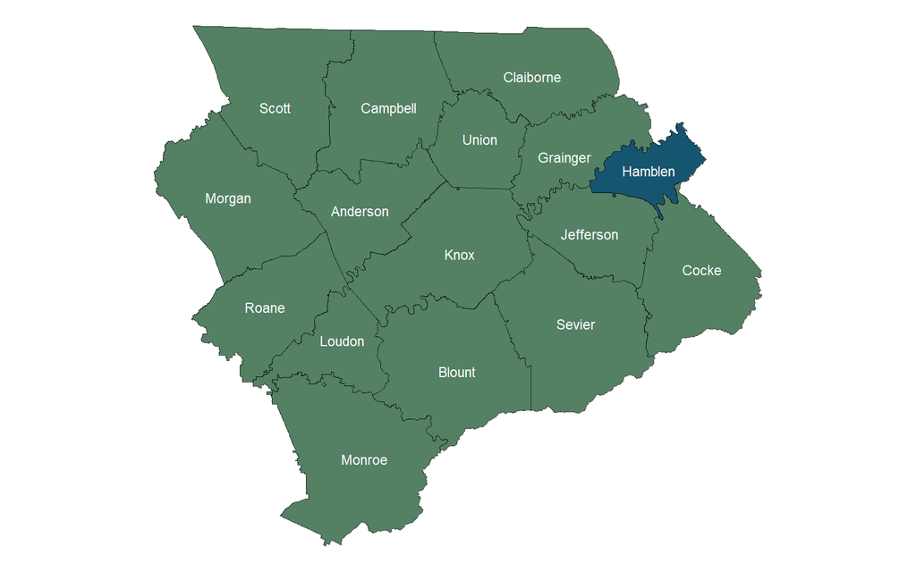

**Population and Growth**

| Place | 1970 | 1980 | 1990 | 2000 | 2010 | 2020 | Change 1970-1980 | Change 1980-1990 | Change 1990-2000 | Change 2000-2010 | Change 2010-2020 |
| --- | --- | --- | --- | --- | --- | --- | --- | --- | --- | --- | --- |
| Hamblen County | 38696 | 49300 | 50480 | 58128 | 62544 | 64499 | 10604 | 1180 | 7648 | 4416 | 1955 |
| Morristown | 20318 | 19683 | 21385 | 24965 | 29137 | 30431 | -635 | 1702 | 3580 | 4172 | 1294 |

[interactive chart not shown]

IPUMS NHGIS, University of Minnesota, www.nhgis.org

**Population Density**

| Place | Area | Population Density |
| --- | --- | --- |
| Hamblen County | 175.7682081636229 | 366.9548701319057 |
| Morristown | 27.66140344980645 | 1100.124946849468 |

[interactive chart not shown]

source: U. S. Census Bureau *Decennial Census: Redistricting Data (PL 94-171)*, 2020, accessed June 2, 2026, http://api.census.gov/data/2020/dec/pl.

**Population Descriptions**

| Place | Year | Race Category | Number of People | Percentage of People |
| --- | --- | --- | --- | --- |
| Hamblen County | 2020 | Black | 2206 | 0.02323817549773517 |
| Hamblen County | 2020 | Other | 11050 | 0.1164015590435057 |
| Hamblen County | 2020 | White | 51243 | 0.5397977457073633 |
| Morristown | 2020 | Black | 1691 | 0.0178131254608659 |
| Morristown | 2020 | Other | 8014 | 0.08442009902033076 |
| Morristown | 2020 | White | 20726 | 0.2183292952701991 |

| Place | Sex | Age Range | Year | Number of People | Percentage of People |
| --- | --- | --- | --- | --- | --- |
| Hamblen County | Female | 10 to 14 years | 2020 | 2433 | 0.02578259118750397 |
| Hamblen County | Female | 15 to 19 years | 2020 | 1974 | 0.020918551173092 |
| Hamblen County | Female | 20 to 24 years | 2020 | 1848 | 0.01958332450246911 |
| Hamblen County | Female | 25 to 29 years | 2020 | 1937 | 0.02052646080155988 |
| Hamblen County | Female | 30 to 34 years | 2020 | 1757 | 0.01861899412924146 |
| Hamblen County | Female | 35 to 39 years | 2020 | 2005 | 0.02124705932221351 |
| Hamblen County | Female | 40 to 44 years | 2020 | 2032 | 0.02153317932306127 |
| Hamblen County | Female | 45 to 49 years | 2020 | 2103 | 0.0222855689549202 |
| Hamblen County | Female | 5 to 9 years | 2020 | 1697 | 0.01798317190513532 |
| Hamblen County | Female | 50 to 54 years | 2020 | 2163 | 0.02292139117902635 |

[output cut: 62 more lines]

[interactive chart not shown]

source: U. S. Census Bureau *Decennial Census: Redistricting Data (PL 94-171)*, 2020, accessed June 2, 2026, http://api.census.gov/data/2020/dec/pl.

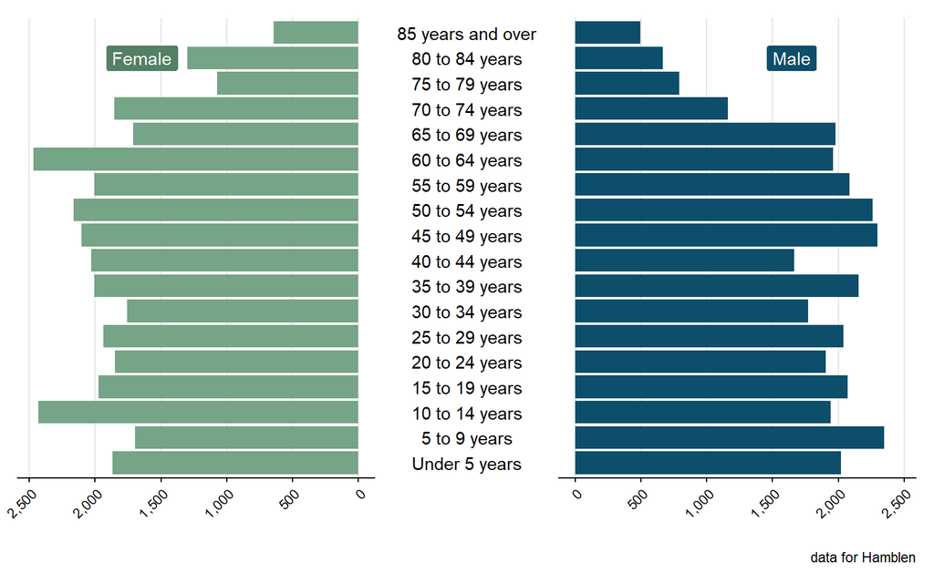

source: U. S. Census Bureau *American Community Survey 5-Year Estimates: Comparison Profiles 5-Year*, 2020, accessed June 2, 2026, http://api.census.gov/data/2020/acs/acs5.

**Education**

| Place | Level of Education | Year | Number of People | Percentage of People |
| --- | --- | --- | --- | --- |
| Hamblen County | 9th to 12th Grade, No Diploma | 2010 | 3884 | 0.06364083237751925 |
| Hamblen County | Associate's degree | 2010 | 2359 | 0.0386531214156972 |
| Hamblen County | Bachelor's degree | 2010 | 4004 | 0.0656070784859905 |
| Hamblen County | Graduate or Professional Degree | 2010 | 2579 | 0.04225790594789448 |
| Hamblen County | Less Than 9th Grade | 2010 | 4399 | 0.07207930525970833 |
| Hamblen County | Some College, No Degree | 2010 | 8705 | 0.1426347697853515 |
| Hamblen County | Total | 2010 | 42091 | 0.689677207930526 |
| Hamblen County | 9th to 12th Grade, No Diploma | 2020 | 3791 | 0.05894150937529152 |
| Hamblen County | Associate's degree | 2020 | 3373 | 0.05244255107434933 |
| Hamblen County | Bachelor's degree | 2020 | 5322 | 0.08274511023352717 |

[output cut: 18 more lines]

[interactive chart not shown]

source: U. S. Census Bureau *American Community Survey 5-Year Estimates: Comparison Profiles 5-Year*, 2020, accessed June 2, 2026, http://api.census.gov/data/2020/acs/acs5.

**Housing Units by Year of Construction**

| Place | Year | 1939 or earlier | 1940-1959 | 1960-1979 | 1980 to 1989 | 1990 to 1999 | 2000 to 2004 | 2005 or later | 2000 to 2009 | 2010 or later | Total |
| --- | --- | --- | --- | --- | --- | --- | --- | --- | --- | --- | --- |
| Hamblen County | 2010 | 1464 | 4386 | 9705 | 4377 | 4473 | 1592 | 736 |  |  | 26733 |
| Hamblen County | 2020 | 766 | 4024 | 9832 | 3790 | 5460 |  |  | 2281 | 1087 | 27240 |
| Morristown | 2010 | 862 | 3249 | 4204 | 2105 | 1612 | 484 | 191 |  |  | 12707 |
| Morristown | 2020 | 336 | 2911 | 4562 | 1277 | 2546 |  |  | 917 | 612 | 13161 |

[interactive chart not shown]

source: U. S. Census Bureau *Decennial Census: Redistricting Data (PL 94-171)*, 2020, accessed June 2, 2026, http://api.census.gov/data/2020/dec/pl.

**Housing Units by Type of Tenure**

| Place | Year | Own | Rent | Total |
| --- | --- | --- | --- | --- |
| Hamblen County | 2010 | 17438 | 7013 | 24451 |
| Hamblen County | 2020 | 16349 | 8141 | 24490 |
| Morristown | 2010 | 6527 | 4863 | 11390 |
| Morristown | 2020 | 5731 | 6026 | 11757 |

[interactive chart not shown]

source: U. S. Census Bureau *Decennial Census: Redistricting Data (PL 94-171)*, 2020, accessed June 2, 2026, http://api.census.gov/data/2020/dec/pl.

**Income Comparison**

| Place | Year | Median Family Income | Median Household Income | Per Capita Income |
| --- | --- | --- | --- | --- |
| Hamblen County | 2020 | 57338 | 43151 | 23722 |
| Morristown | 2020 | 43054 | 33511 | 19457 |

[interactive chart not shown]

source: U. S. Census Bureau *Decennial Census: Redistricting Data (PL 94-171)*, 2020, accessed June 2, 2026, http://api.census.gov/data/2020/dec/pl.

**Povery Status**

| Place | Year | Above Poverty | Below Poverty |
| --- | --- | --- | --- |
| Hamblen County | 2020 | 14140 | 1947 |
| Morristown | 2020 | 5165 | 1516 |

[interactive chart not shown]

source: U. S. Census Bureau *American Community Survey 5-Year Estimates: Comparison Profiles 5-Year*, 2020, accessed June 2, 2026, http://api.census.gov/data/2020/acs/acs5.

**Poverty Status by Family Type**

| Place | Poverty Status | Family Type | Number of Families | Year | Percentage of Families |
| --- | --- | --- | --- | --- | --- |
| Hamblen County | Above Poverty | All Families | 14140 | 2020 | 0.6210470836261419 |
| Hamblen County | Above Poverty | Female Householder | 1862 | 2020 | 0.0817814476458187 |
| Hamblen County | Above Poverty | Female Householder with related children | 1060 | 2020 | 0.04655657062543921 |
| Hamblen County | Below Poverty | All Families | 1947 | 2020 | 0.0855147575544624 |
| Hamblen County | Below Poverty | Female Householder | 923 | 2020 | 0.04053935347856641 |
| Hamblen County | Below Poverty | Female Householder with related children | 837 | 2020 | 0.03676212227687983 |
| Morristown | Above Poverty | All Families | 5165 | 2020 | 0.226853478566409 |
| Morristown | Above Poverty | Female Householder | 937 | 2020 | 0.04115425158116655 |
| Morristown | Above Poverty | Female Householder with related children | 580 | 2020 | 0.02547434996486296 |
| Morristown | Below Poverty | All Families | 1516 | 2020 | 0.06658468025298665 |

[output cut: 2 more lines]

[interactive chart not shown]

source: U. S. Census Bureau *American Community Survey 5-Year Estimates: Comparison Profiles 5-Year*, 2020, accessed June 2, 2026, http://api.census.gov/data/2020/acs/acs5.

**Employment by Industry**

| Place | Industry | Year | Number of Jobs | Percentage of Jobs |
| --- | --- | --- | --- | --- |
| Hamblen County | Arts, Entertainment, And Recreation, And Accommodation And Food Services | 2010 | 2077 | 0.07758395278472975 |
| Hamblen County | Arts, Entertainment, And Recreation, And Accommodation And Food Services | 2020 | 3192 | 0.2735687350017141 |
| Hamblen County | Educational Services, And Health Care And Social Assistance | 2010 | 5092 | 0.1902058197303052 |
| Hamblen County | Educational Services, And Health Care And Social Assistance | 2020 | 5183 | 0.4442063764141241 |
| Hamblen County | Manufacturing | 2010 | 6961 | 0.260020171080647 |
| Hamblen County | Manufacturing | 2020 | 6805 | 0.5832190606787796 |
| Hamblen County | Other Industries | 2010 | 9672 | 0.36128646669904 |
| Hamblen County | Other Industries | 2020 | 6469 | 0.5544223517312307 |
| Hamblen County | Professional, Scientific, And Management, And Administrative, And Waste Management Services | 2020 | 1862 | 0.06914478814660775 |
| Hamblen County | Retail Trade | 2010 | 2969 | 0.1109035897052781 |

[output cut: 12 more lines]

[interactive chart not shown]

source: U. S. Census Bureau *American Community Survey 5-Year Estimates: Comparison Profiles 5-Year*, 2020, accessed June 2, 2026, http://api.census.gov/data/2020/acs/acs5.

**Employment by Industry (Historical)**

| Place | Year | Industry | Number of Jobs | Percentage of Jobs |
| --- | --- | --- | --- | --- |
| Hamblen County | 2010 | Agriculture, Forestry, Fishing And Hunting, And Mining | 406 | 0.01058752966333742 |
| Hamblen County | 2010 | Construction | 1878 | 0.04897384410775289 |
| Hamblen County | 2010 | Manufacturing | 6961 | 0.181526586173625 |
| Hamblen County | 2010 | Other | 1409 | 0.03674342191044932 |
| Hamblen County | 2010 | Professional Services | 8990 | 0.2344381568310429 |
| Hamblen County | 2010 | Public Administration | 950 | 0.02477377630583879 |
| Hamblen County | 2010 | Trade, Finance, Insurance &amp; Real Estate | 6177 | 0.1610817013064907 |
| Hamblen County | 2020 | Agriculture, Forestry, Fishing And Hunting, And Mining | 195 | 0.005052206130010104 |
| Hamblen County | 2020 | Construction | 1529 | 0.03961447780915615 |
| Hamblen County | 2020 | Manufacturing | 6805 | 0.1763090395626603 |

[output cut: 18 more lines]

**Labor Force by Place of Work**

| Place | Year | Work Out Of State | Work Out of County of Residence | Work in County of Residence |
| --- | --- | --- | --- | --- |
| Hamblen County | 2020 | 98 | 6573 | 19902 |
| Morristown | 2020 | 43 | 2445 | 9005 |

[interactive chart not shown]

source: U. S. Census Bureau *American Community Survey 5-Year Estimates: Comparison Profiles 5-Year*, 2020, accessed June 2, 2026, http://api.census.gov/data/2020/acs/acs5.

**Commuting Patterns**

| Home County | Year | Number of Jobs | Percentage of Jobs |
| --- | --- | --- | --- |
| Hamblen | 2010 | 13261 | 0.2236256323777403 |
| Hamblen | 2020 | 13009 | 0.2193760539629005 |
| Jefferson | 2020 | 3291 | 0.05549747048903879 |
| Jefferson | 2010 | 2901 | 0.04892074198988196 |
| Greene | 2020 | 1402 | 0.0236424957841484 |
| Knox | 2020 | 1267 | 0.02136593591905565 |
| Knox | 2010 | 1248 | 0.02104553119730185 |
| Greene | 2010 | 1147 | 0.01934232715008432 |
| Sevier | 2020 | 738 | 0.01244519392917369 |
| Sevier | 2010 | 675 | 0.01138279932546374 |

[output cut: 3 more lines]

| Work County | Year | Number of Jobs | Percentage of Jobs |
| --- | --- | --- | --- |
| Hamblen | 2010 | 13261 | 0.2236256323777403 |
| Hamblen | 2020 | 13009 | 0.2193760539629005 |
| Jefferson | 2020 | 1812 | 0.03055649241146711 |
| Jefferson | 2010 | 1471 | 0.02480607082630691 |
| Hawkins | 2020 | 425 | 0.007166947723440135 |
| Cocke | 2010 | 395 | 0.006661045531197302 |
| Grainger | 2020 | 392 | 0.006610455311973019 |
| Cocke | 2020 | 387 | 0.006526138279932547 |
| Hawkins | 2010 | 350 | 0.005902192242833052 |
| Grainger | 2010 | 241 | 0.004064080944350758 |

[output cut: 3 more lines]

[interactive chart not shown]

source: U. S. Census Bureau *Tn_od_main_JT00_2020*, LEHD Origin-Destination Employment Statistics, 8.3, 2020, accessed June 2, 2026, https://lehd.ces.census.gov/data/lodes/.

## References

Bureau, U. S. Census. *American Community Survey 5-Year Estimates: Comparison Profiles 5-Year*. 2020. Accessed June 2, 2026. http://api.census.gov/data/2020/acs/acs5.

Bureau, U. S. Census. *Decennial Census: Redistricting Data (PL 94-171)*. 2020. Accessed June 2, 2026. http://api.census.gov/data/2020/dec/pl.

Bureau, U. S. Census. *Tn_od_main_JT00_2020*. LEHD Origin-Destination Employment Statistics, 8.3. 2020. Accessed June 2, 2026. https://lehd.ces.census.gov/data/lodes/.